# Risk Factor Analysis

## Outcome Variable

**Outcome Variable:** sstunted

## Predictor Variables

**Intervention Variable:** fhtcm

**Adjustment Set:**

unadjusted

## Stratifying Variables

The analysis was stratified on these variable(s):

- agecat
- studyid
- country

## Data Summary

| agecat | studyid | country | A | n | nA | nAY0 | nAY1 |
| --- | --- | --- | --- | --- | --- | --- | --- |
| Birth | ki1101329-Keneba | GAMBIA | [160-170) | 1165 | 631 | 620 | 11 |
| Birth | ki1101329-Keneba | GAMBIA | <160 | 1165 | 27 | 27 | 0 |
| Birth | ki1101329-Keneba | GAMBIA | >=170 | 1165 | 507 | 497 | 10 |
| Birth | ki1135781-COHORTS | GUATEMALA | [160-170) | 91 | 53 | 53 | 0 |
| Birth | ki1135781-COHORTS | GUATEMALA | <160 | 91 | 32 | 32 | 0 |
| Birth | ki1135781-COHORTS | GUATEMALA | >=170 | 91 | 6 | 4 | 2 |
| 3 months | ki1000304b-SAS-FoodSuppl | INDIA | [160-170) | 92 | 59 | 54 | 5 |
| 3 months | ki1000304b-SAS-FoodSuppl | INDIA | <160 | 92 | 22 | 17 | 5 |
| 3 months | ki1000304b-SAS-FoodSuppl | INDIA | >=170 | 92 | 11 | 10 | 1 |
| 3 months | ki1101329-Keneba | GAMBIA | [160-170) | 1562 | 859 | 828 | 31 |
| 3 months | ki1101329-Keneba | GAMBIA | <160 | 1562 | 36 | 35 | 1 |
| 3 months | ki1101329-Keneba | GAMBIA | >=170 | 1562 | 667 | 653 | 14 |
| 3 months | ki1135781-COHORTS | GUATEMALA | [160-170) | 140 | 75 | 70 | 5 |
| 3 months | ki1135781-COHORTS | GUATEMALA | <160 | 140 | 53 | 42 | 11 |
| 3 months | ki1135781-COHORTS | GUATEMALA | >=170 | 140 | 12 | 11 | 1 |
| 6 months | ki1000304b-SAS-FoodSuppl | INDIA | [160-170) | 94 | 60 | 54 | 6 |
| 6 months | ki1000304b-SAS-FoodSuppl | INDIA | <160 | 94 | 23 | 19 | 4 |
| 6 months | ki1000304b-SAS-FoodSuppl | INDIA | >=170 | 94 | 11 | 7 | 4 |
| 6 months | ki1101329-Keneba | GAMBIA | [160-170) | 1511 | 828 | 795 | 33 |
| 6 months | ki1101329-Keneba | GAMBIA | <160 | 1511 | 34 | 33 | 1 |
| 6 months | ki1101329-Keneba | GAMBIA | >=170 | 1511 | 649 | 634 | 15 |
| 6 months | ki1135781-COHORTS | GUATEMALA | [160-170) | 151 | 86 | 74 | 12 |
| 6 months | ki1135781-COHORTS | GUATEMALA | <160 | 151 | 54 | 39 | 15 |
| 6 months | ki1135781-COHORTS | GUATEMALA | >=170 | 151 | 11 | 10 | 1 |
| 9 months | ki1000304b-SAS-FoodSuppl | INDIA | [160-170) | 84 | 54 | 44 | 10 |
| 9 months | ki1000304b-SAS-FoodSuppl | INDIA | <160 | 84 | 22 | 15 | 7 |
| 9 months | ki1000304b-SAS-FoodSuppl | INDIA | >=170 | 84 | 8 | 5 | 3 |
| 9 months | ki1101329-Keneba | GAMBIA | [160-170) | 1529 | 840 | 785 | 55 |
| 9 months | ki1101329-Keneba | GAMBIA | <160 | 1529 | 35 | 33 | 2 |
| 9 months | ki1101329-Keneba | GAMBIA | >=170 | 1529 | 654 | 632 | 22 |
| 9 months | ki1135781-COHORTS | GUATEMALA | [160-170) | 164 | 87 | 64 | 23 |
| 9 months | ki1135781-COHORTS | GUATEMALA | <160 | 164 | 65 | 39 | 26 |
| 9 months | ki1135781-COHORTS | GUATEMALA | >=170 | 164 | 12 | 10 | 2 |
| 12 months | ki1000304b-SAS-FoodSuppl | INDIA | [160-170) | 91 | 59 | 34 | 25 |
| 12 months | ki1000304b-SAS-FoodSuppl | INDIA | <160 | 91 | 23 | 11 | 12 |
| 12 months | ki1000304b-SAS-FoodSuppl | INDIA | >=170 | 91 | 9 | 5 | 4 |
| 12 months | ki1101329-Keneba | GAMBIA | [160-170) | 1448 | 805 | 732 | 73 |
| 12 months | ki1101329-Keneba | GAMBIA | <160 | 1448 | 32 | 31 | 1 |
| 12 months | ki1101329-Keneba | GAMBIA | >=170 | 1448 | 611 | 585 | 26 |
| 12 months | ki1135781-COHORTS | GUATEMALA | [160-170) | 204 | 112 | 72 | 40 |
| 12 months | ki1135781-COHORTS | GUATEMALA | <160 | 204 | 78 | 41 | 37 |
| 12 months | ki1135781-COHORTS | GUATEMALA | >=170 | 204 | 14 | 10 | 4 |
| 18 months | ki1000304b-SAS-FoodSuppl | INDIA | [160-170) | 83 | 54 | 33 | 21 |
| 18 months | ki1000304b-SAS-FoodSuppl | INDIA | <160 | 83 | 21 | 8 | 13 |
| 18 months | ki1000304b-SAS-FoodSuppl | INDIA | >=170 | 83 | 8 | 5 | 3 |
| 18 months | ki1101329-Keneba | GAMBIA | [160-170) | 1445 | 823 | 718 | 105 |
| 18 months | ki1101329-Keneba | GAMBIA | <160 | 1445 | 30 | 26 | 4 |
| 18 months | ki1101329-Keneba | GAMBIA | >=170 | 1445 | 592 | 565 | 27 |
| 18 months | ki1135781-COHORTS | GUATEMALA | [160-170) | 188 | 106 | 54 | 52 |
| 18 months | ki1135781-COHORTS | GUATEMALA | <160 | 188 | 68 | 25 | 43 |
| 18 months | ki1135781-COHORTS | GUATEMALA | >=170 | 188 | 14 | 8 | 6 |
| 24 months | ki1101329-Keneba | GAMBIA | [160-170) | 1297 | 729 | 651 | 78 |
| 24 months | ki1101329-Keneba | GAMBIA | <160 | 1297 | 27 | 24 | 3 |
| 24 months | ki1101329-Keneba | GAMBIA | >=170 | 1297 | 541 | 518 | 23 |
| 24 months | ki1135781-COHORTS | GUATEMALA | [160-170) | 240 | 135 | 64 | 71 |
| 24 months | ki1135781-COHORTS | GUATEMALA | <160 | 240 | 89 | 39 | 50 |
| 24 months | ki1135781-COHORTS | GUATEMALA | >=170 | 240 | 16 | 11 | 5 |

The following strata were considered:

- agecat: 12 months, studyid: ki1000304b-SAS-FoodSuppl, country: INDIA
- agecat: 12 months, studyid: ki1101329-Keneba, country: GAMBIA
- agecat: 12 months, studyid: ki1135781-COHORTS, country: GUATEMALA
- agecat: 18 months, studyid: ki1000304b-SAS-FoodSuppl, country: INDIA
- agecat: 18 months, studyid: ki1101329-Keneba, country: GAMBIA
- agecat: 18 months, studyid: ki1135781-COHORTS, country: GUATEMALA
- agecat: 24 months, studyid: ki1101329-Keneba, country: GAMBIA
- agecat: 24 months, studyid: ki1135781-COHORTS, country: GUATEMALA
- agecat: 3 months, studyid: ki1000304b-SAS-FoodSuppl, country: INDIA
- agecat: 3 months, studyid: ki1101329-Keneba, country: GAMBIA
- agecat: 3 months, studyid: ki1135781-COHORTS, country: GUATEMALA
- agecat: 6 months, studyid: ki1000304b-SAS-FoodSuppl, country: INDIA
- agecat: 6 months, studyid: ki1101329-Keneba, country: GAMBIA
- agecat: 6 months, studyid: ki1135781-COHORTS, country: GUATEMALA
- agecat: 9 months, studyid: ki1000304b-SAS-FoodSuppl, country: INDIA
- agecat: 9 months, studyid: ki1101329-Keneba, country: GAMBIA
- agecat: 9 months, studyid: ki1135781-COHORTS, country: GUATEMALA
- agecat: Birth, studyid: ki1101329-Keneba, country: GAMBIA
- agecat: Birth, studyid: ki1135781-COHORTS, country: GUATEMALA

### Dropped Strata

Some strata were dropped due to rare outcomes:

- agecat: Birth, studyid: ki1101329-Keneba, country: GAMBIA
- agecat: Birth, studyid: ki1135781-COHORTS, country: GUATEMALA
- agecat: 3 months, studyid: ki1000304b-SAS-FoodSuppl, country: INDIA
- agecat: 3 months, studyid: ki1101329-Keneba, country: GAMBIA
- agecat: 3 months, studyid: ki1135781-COHORTS, country: GUATEMALA
- agecat: 6 months, studyid: ki1000304b-SAS-FoodSuppl, country: INDIA
- agecat: 6 months, studyid: ki1101329-Keneba, country: GAMBIA
- agecat: 6 months, studyid: ki1135781-COHORTS, country: GUATEMALA
- agecat: 9 months, studyid: ki1000304b-SAS-FoodSuppl, country: INDIA
- agecat: 9 months, studyid: ki1101329-Keneba, country: GAMBIA
- agecat: 9 months, studyid: ki1135781-COHORTS, country: GUATEMALA
- agecat: 12 months, studyid: ki1000304b-SAS-FoodSuppl, country: INDIA
- agecat: 12 months, studyid: ki1101329-Keneba, country: GAMBIA
- agecat: 12 months, studyid: ki1135781-COHORTS, country: GUATEMALA
- agecat: 18 months, studyid: ki1000304b-SAS-FoodSuppl, country: INDIA
- agecat: 18 months, studyid: ki1101329-Keneba, country: GAMBIA
- agecat: 24 months, studyid: ki1101329-Keneba, country: GAMBIA

## Methods Detail

We’re interested in the causal parameters $E[Y_a]$ for all values of $a \in \mathcal{A}$. These parameters represent the mean outcome if, possibly contrary to fact, we intervened to set all units to have $A=a$. Under the randomization and positivity assumptions, these are identified by the statistical parameters $\psi_a=E_W[E_{Y|A,W}(Y|A=a,W)]$. In addition, we’re interested in the mean of $Y$, $E[Y]$ under no intervention (the observed mean). We will estimate these parameters by using SuperLearner to fit the relevant likelihood factors – $E_{Y|A,W}(Y|A=a,W)$ and $p(A=a|W)$, and then updating our likelihood fit using a joint TMLE.

For unadjusted analyses ($W=\{\}$), initial likelihoods were estimated using Lrnr_glm to estimate the simple $E(Y|A)$ and Lrnr_mean to estimate $p(A)$. For adjusted analyses, a small library containing Lrnr_glmnet, Lrnr_xgboost, and Lrnr_mean was used.

Having estimated these parameters, we will then use the delta method to estimate relative risks and attributable risks relative to a prespecified baseline level of $A$.

# Results Detail

## Results Plots

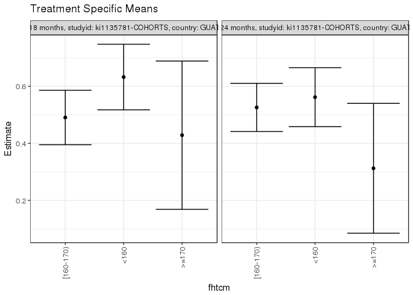

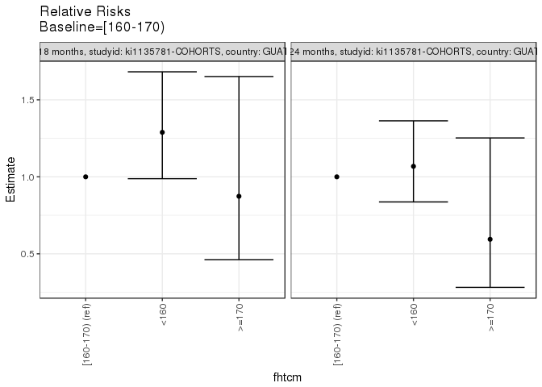

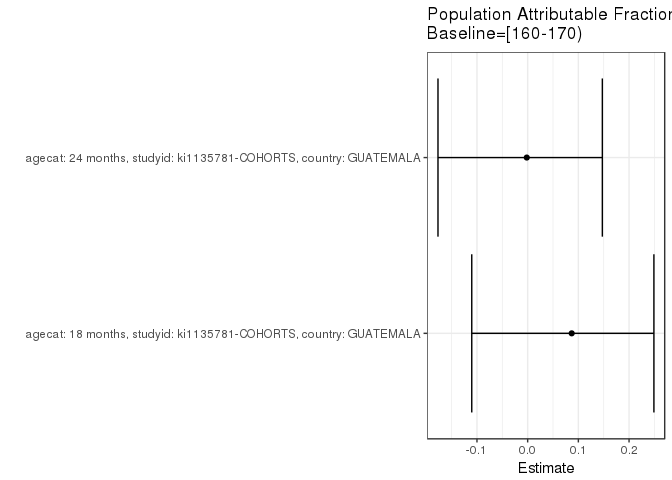

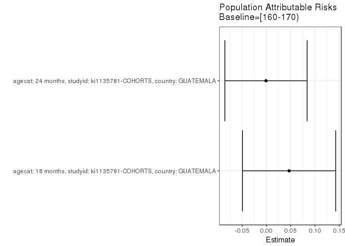

## Results Table

### Parameter: TSM

| agecat | studyid | country | intervention_level | baseline_level | estimate | ci_lower | ci_upper |
| --- | --- | --- | --- | --- | --- | --- | --- |
| 18 months | ki1135781-COHORTS | GUATEMALA | [160-170) | NA | 0.4905660 | 0.3951446 | 0.5859875 |
| 18 months | ki1135781-COHORTS | GUATEMALA | <160 | NA | 0.6323529 | 0.5174458 | 0.7472601 |
| 18 months | ki1135781-COHORTS | GUATEMALA | >=170 | NA | 0.4285714 | 0.1686544 | 0.6884885 |
| 24 months | ki1135781-COHORTS | GUATEMALA | [160-170) | NA | 0.5259259 | 0.4415199 | 0.6103319 |
| 24 months | ki1135781-COHORTS | GUATEMALA | <160 | NA | 0.5617978 | 0.4585009 | 0.6650946 |
| 24 months | ki1135781-COHORTS | GUATEMALA | >=170 | NA | 0.3125000 | 0.0849085 | 0.5400915 |

### Parameter: E(Y)

| agecat | studyid | country | intervention_level | baseline_level | estimate | ci_lower | ci_upper |
| --- | --- | --- | --- | --- | --- | --- | --- |
| 18 months | ki1135781-COHORTS | GUATEMALA | NA | NA | 0.537234 | 0.5267214 | 0.5477466 |
| 24 months | ki1135781-COHORTS | GUATEMALA | NA | NA | 0.525000 | 0.5174857 | 0.5325143 |

### Parameter: RR

| agecat | studyid | country | intervention_level | baseline_level | estimate | ci_lower | ci_upper |
| --- | --- | --- | --- | --- | --- | --- | --- |
| 18 months | ki1135781-COHORTS | GUATEMALA | [160-170) | [160-170) | 1.0000000 | 1.0000000 | 1.000000 |
| 18 months | ki1135781-COHORTS | GUATEMALA | <160 | [160-170) | 1.2890271 | 0.9877768 | 1.682152 |
| 18 months | ki1135781-COHORTS | GUATEMALA | >=170 | [160-170) | 0.8736264 | 0.4620856 | 1.651692 |
| 24 months | ki1135781-COHORTS | GUATEMALA | [160-170) | [160-170) | 1.0000000 | 1.0000000 | 1.000000 |
| 24 months | ki1135781-COHORTS | GUATEMALA | <160 | [160-170) | 1.0682070 | 0.8368777 | 1.363480 |
| 24 months | ki1135781-COHORTS | GUATEMALA | >=170 | [160-170) | 0.5941901 | 0.2818663 | 1.252587 |

### Parameter: PAR

| agecat | studyid | country | intervention_level | baseline_level | estimate | ci_lower | ci_upper |
| --- | --- | --- | --- | --- | --- | --- | --- |
| 18 months | ki1135781-COHORTS | GUATEMALA | [160-170) | NA | 0.0466680 | -0.0493308 | 0.1426668 |
| 24 months | ki1135781-COHORTS | GUATEMALA | [160-170) | NA | -0.0009259 | -0.0856657 | 0.0838139 |

### Parameter: PAF

| agecat | studyid | country | intervention_level | baseline_level | estimate | ci_lower | ci_upper |
| --- | --- | --- | --- | --- | --- | --- | --- |
| 18 months | ki1135781-COHORTS | GUATEMALA | [160-170) | NA | 0.0868672 | -0.1102895 | 0.2490143 |
| 24 months | ki1135781-COHORTS | GUATEMALA | [160-170) | NA | -0.0017637 | -0.1769065 | 0.1473150 |